# Student test performance

Drey Upsher-Obear

# Data

Load data, check structure for variable types.

```r
dat <- read.csv("StudentsPerformance.csv", sep = ",", stringsAsFactors = TRUE)

str(dat)
```

```
## 'data.frame':    1000 obs. of  8 variables:
##  $ gender                     : Factor w/ 2 levels "female","male": 1 1 1 2 2 1 1 2 2 1 ...
##  $ race.ethnicity             : Factor w/ 5 levels "group A","group B",..: 2 3 2 1 3 2 2 2 4 2 ...
##  $ parental.level.of.education: Factor w/ 6 levels "associate's degree",..: 2 5 4 1 5 1 5 5 3 3 ...
##  $ lunch                      : Factor w/ 2 levels "free/reduced",..: 2 2 2 1 2 2 2 1 1 1 ...
##  $ test.preparation.course    : Factor w/ 2 levels "completed","none": 2 1 2 2 2 2 1 2 1 2 ...
##  $ math.score                 : int  72 69 90 47 76 71 88 40 64 38 ...
##  $ reading.score              : int  72 90 95 57 78 83 95 43 64 60 ...
##  $ writing.score              : int  74 88 93 44 75 78 92 39 67 50 ...
```

## Implied correlation

Using the wonderful DataExplorer package, lets check the distribution of our variables.

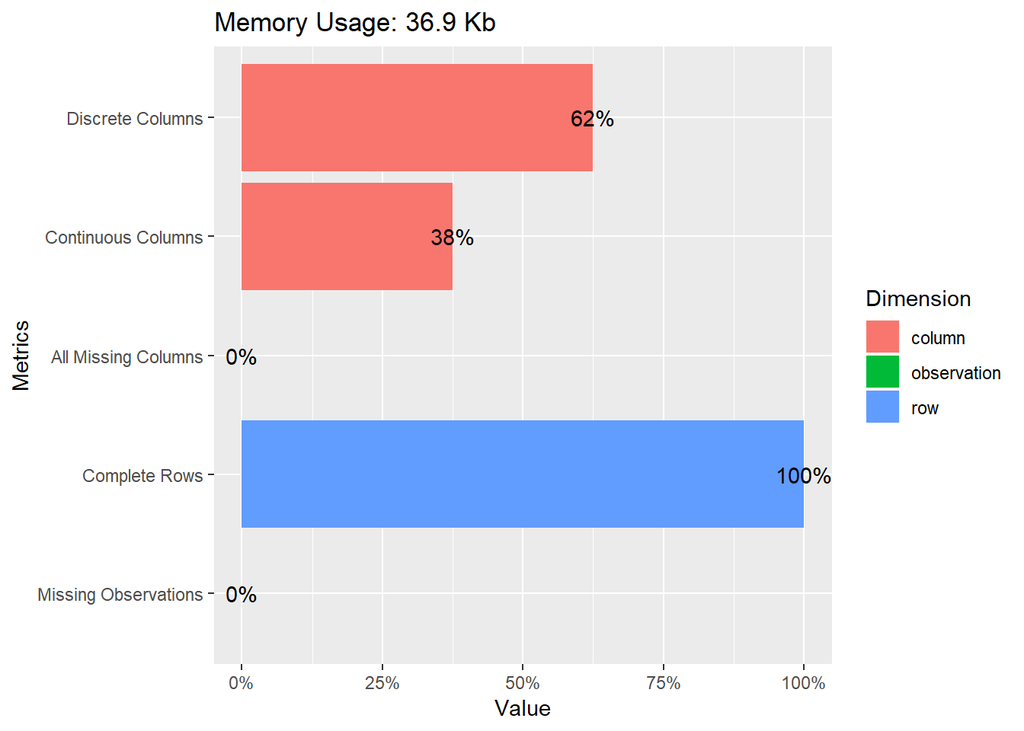

A bit of a unicorn, no missing observations and no missing columns. Very little cleaning is necessary.

Now lets check for correlation between variables.

```
## 2 features with more than 4 categories ignored!
## race.ethnicity: 5 categories
## parental.level.of.education: 6 categories
```

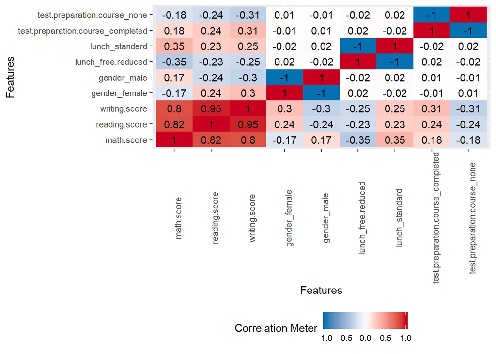

```r
dat %>%
  plot_correlation(maxcat = 4)
```

Interesting, we have a pretty good idea of what to expect correlation wise with the variables.

## Question 1

Step 1: organize data into a more readable form, then plot. Examining reading score first. I didn’t want to reorganize the DF into a long form, so I will plot the 3 scores on separate plots. This will change eventually to a faceted graph.

```r
par.edu <- dat %>%
  group_by(parental.level.of.education) %>%
  summarise(avg_mat = mean(math.score),
            avg_writ = mean(writing.score),
            avg_read = mean(reading.score))

par.edu
```

```
## # A tibble: 6 x 4
##   parental.level.of.education avg_mat avg_writ avg_read
##   <fct>                         <dbl>    <dbl>    <dbl>
## 1 associate's degree             67.9     69.9     70.9
## 2 bachelor's degree              69.4     73.4     73
## 3 high school                    62.1     62.4     64.7
## 4 master's degree                69.7     75.7     75.4
## 5 some college                   67.1     68.8     69.5
## 6 some high school               63.5     64.9     66.9
```

Plot for reading score.

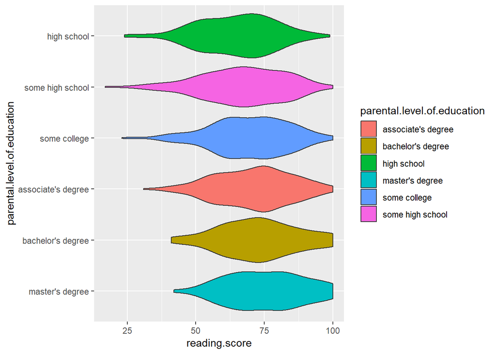

```r
dat %>%
  ggplot(aes(parental.level.of.education, fill = parental.level.of.education)) +
  geom_violin(aes(x = reorder(parental.level.of.education, -reading.score), y = reading.score)) +
  coord_flip()
```

Plot for writing score.

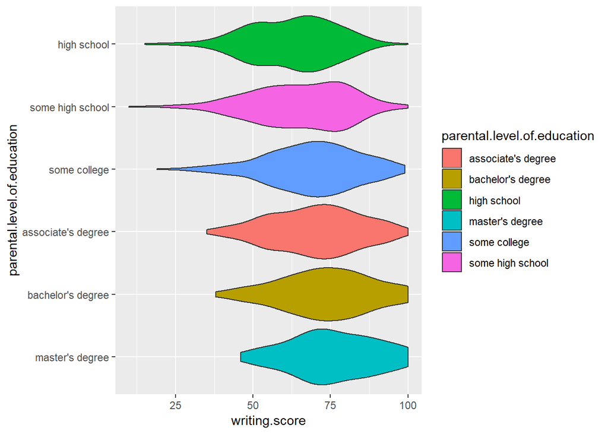

```r
dat %>%
  ggplot(aes(parental.level.of.education, fill = parental.level.of.education)) +
  geom_violin(aes(x = reorder(parental.level.of.education, -writing.score), y = writing.score)) +
  coord_flip()
```

Plot for mathematics score.

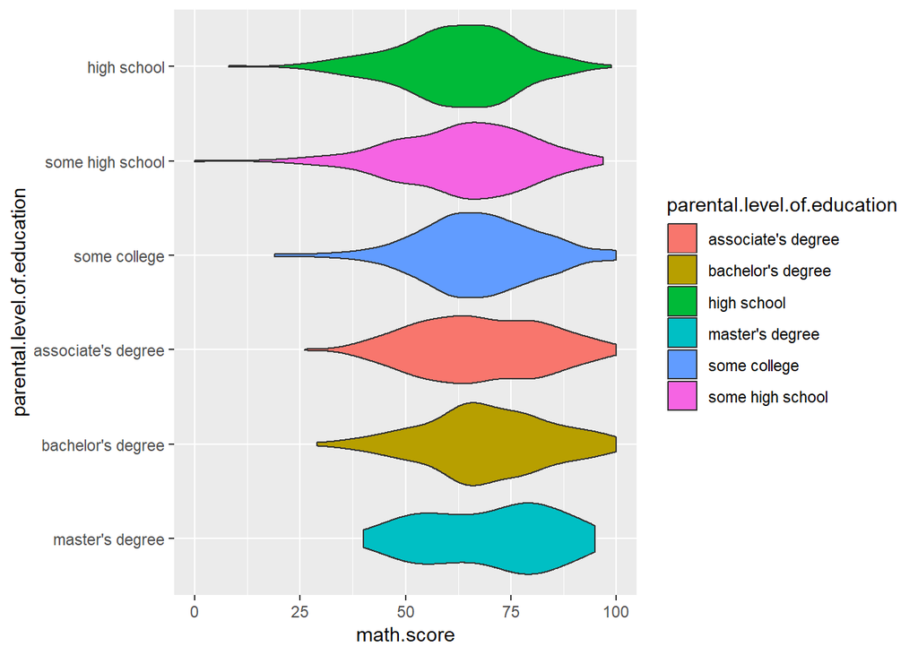

```r
dat %>%
  ggplot(aes(parental.level.of.education, fill = parental.level.of.education)) +
  geom_violin(aes(x = reorder(parental.level.of.education, -math.score), y = math.score)) +
  coord_flip()
```

From these plots, it makes sense to accept our hypothesis. Students that have more educated parents do indeed score higher on reading, writing, and mathematics testing. However, how do we control for the study variable? (IE, prepared or not for test).

## Question 2

Do students that have free or reduced lunch score better or worse on average than those who have a secure pantry?

Math scores first.

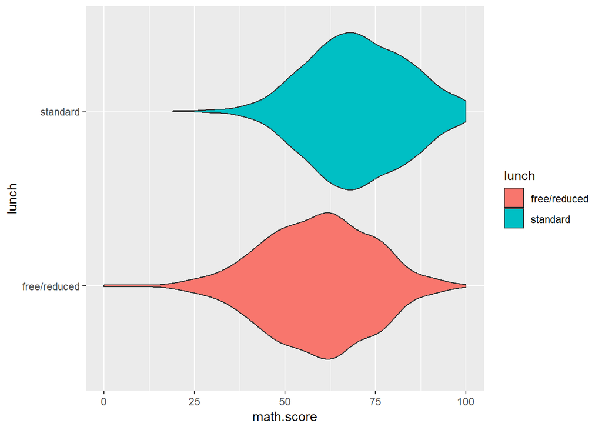

```r
dat %>%
  ggplot(aes(x = lunch, y = math.score, fill = lunch)) +
  geom_violin() +
  coord_flip()
```

Reading scores second.

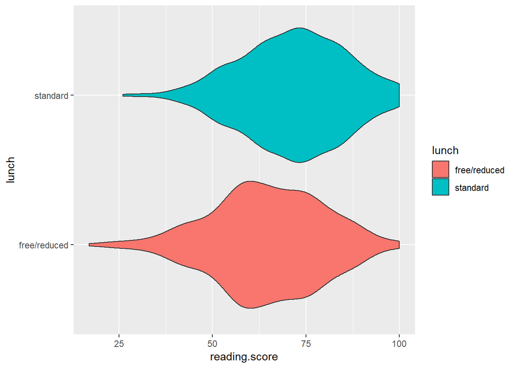

```r
dat %>%
  ggplot(aes(x = lunch, y = reading.score, fill = lunch)) +
  geom_violin() +
  coord_flip()
```

Writing score last.

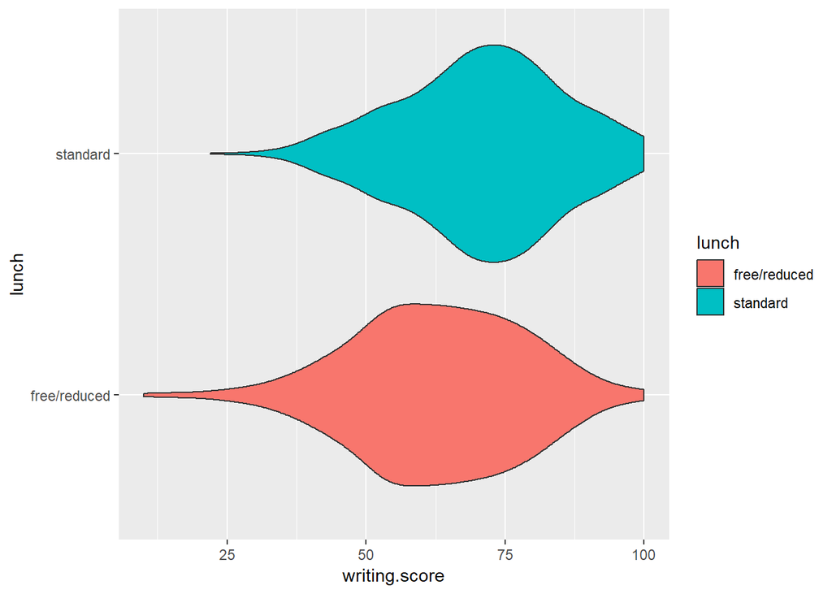

```r
dat %>%
  ggplot(aes(x = lunch, y = writing.score, fill = lunch)) +
  geom_violin() +
  coord_flip()
```

## Question 2 conclusion

I think it would be very safe to say that students that get free/reduced lunch not only perform slightly worse, but also have a greater range of possible scores on testing.